# Age-Standardization

Yulin

04/12/2022

## What is age-standardization

Mortality rate is the death number at a specified population presented in ‰ format. For a particular population, we get the mortality by
$$\frac{\text{number of death}}{\text{particular population}}*1000$$
We call it Crud Mortality Rate(CMR).

When we need to compare the mortality of two populations, can we compare the CRD of two population directly? The anser is normally no. We won’t get the right result if these two populations have two different population pyramids. Because age is the confounding factor that affects the death rate, so for a population with more older age people, its death rate would be higher than a population with less older age people. Thus, age is a confounding factor to death rate comparision between two different populations.

To get rid of the influence of the confounding factor of age, we need to standardize the age structure first and then compare their mortality rate. This process is called age-standardization.

There are two ways to standardize the age: direct age-standardization and indirect age-standardization. Here is an example of direct age-standardization.

#### Let’s look at how the direct age-standardization works through the following example.

The following are the crude mortality rates for two populations: single males and married males.

Single Males

| Age | Pop | Rate | Deaths |
| --- | --- | --- | --- |
| 15-24 | 17,724,000 | 0.00224 | 39,745 |
| 25-44 | 5,390,000 | 0.00489 | 26,372 |
| 45-64 | 1,210,000 | 0.03068 | 37,125 |
| 65-74 | 364,000 | 0.0925 | 33,679 |
| >74 | 119,000 | 0.323 | 64,386 |
| Total | 24,887,000 | 0.008 | 201,307 |

Married Males

| Age | Pop | Rate | Deaths |
| --- | --- | --- | --- |
| 15-24 | 3,427,000 | 0.00214 | 7,327 |
| 25-44 | 23,083,000 | 0.00261 | 60,337 |
| 45-64 | 18,088,000 | 0.016 | 286,535 |
| 65-74 | 5,500,000 | 0.05 | 275,818 |
| >74 | 2,331,000 | 0.118 | 275,135 |
| Total | 54,429,000 | 0.017 | 905,152 |

Looking at these two tables, we can easily get the conclusion: Single males have a much lower death rate (0.008) comparing to married males (0.017).

Is that true? Not really. Because the age structures of two populations (single and married males) are very different. For the single males group, the death rate for people of 75 or above is much higher than that of the married males group, but the number of people in this age group is much less comparing to that of the married males group. Different age structures affect the accurate of the comparing result.

Here is what we’re going to do to adjust the death rate for both populations using direct age-standardization method.

1. Get the death rate by each age group for both populations. In this example we have already had these; otherwise, we would need to calculate to get them.
2. Find a standard population with standard age structure. The purpose is to calculate the death rate for the two populationa using one standard population with standard age structure and as a result, get rid of the influence of the confounding factor of age. We can use any standard population. In this example, we sum the population for each age group to get the standard population. After calculation, we get this population:

Standard Population

| Age | Single_Pop | Married_Pop | sum_pop |
| --- | --- | --- | --- |
| 15-24 | 17,724,000 | 3,427,000 | 21,151,000 |
| 25-44 | 5,390,000 | 23,083,000 | 28,473,000 |
| 45-64 | 1,210,000 | 18,088,000 | 19,298,000 |
| 65-74 | 364,000 | 5,500,000 | 5,864,000 |
| >74 | 119,000 | 2,331,000 | 2,450,000 |
| Total | 24,887,000 | 54,429,000 | 79,316,000 |

3. Use the standard population separately in both group to replace the original population. Then calculate to get the adjusted death rate for both groups.

[1] “21,151,000” “28,473,000” “19,298,000” " 5,864,000" " 2,450,000" “79,316,000”

Single Males

| Age | Pop | Rate | Deaths |
| --- | --- | --- | --- |
| 15-24 | 21,151,000 | 0.00224 | 47,378 |
| 25-44 | 28,473,000 | 0.00489 | 139,233 |
| 45-64 | 19,298,000 | 0.03068 | 592,063 |
| 65-74 | 5,864,000 | 0.09250 | 542,420 |
| >74 | 2,450,000 | 0.32300 | 791,350 |
| Total | 77,236,000 | 0.02735 | 2,112,444 |

Married Males

| Age | Pop | Rate | Deaths |
| --- | --- | --- | --- |
| 15-24 | 21,151,000 | 0.00214 | 45,263 |
| 25-44 | 28,473,000 | 0.00261 | 74,315 |
| 45-64 | 19,298,000 | 0.01600 | 308,768 |
| 65-74 | 5,864,000 | 0.05000 | 293,200 |
| >74 | 2,450,000 | 0.11800 | 289,100 |
| Total | 77,236,000 | 0.01309 | 1,010,646 |

4. Compare use adjusted death rate. Now, we can see that actually, the death rate of single males group is much higher than that of the married males group.

#### Let’s look how indirect age-standardization works through the following example

The following are Ireland’s population pyramid, population, mortality rate, and deaths.

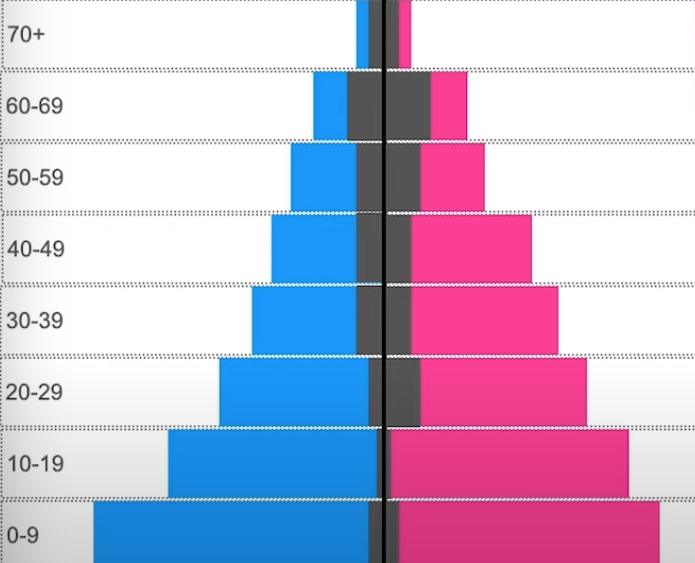

Ireland Population Pyramid

Ireland Mortality Rate

[output not shown]

The actual deaths is 18,300 for Ireland. If we want to compare the death rates between Ireland and European, we can’t use this number to compare because their age structures (or the population pyramids) are different. So we need to get rid of the influence of the confounding factor of age when doing this comparison.

We’re going to use indirect age-standardization.

We use European’s death rate from a standard population (European) to replace the death rate of Ireland.

Ireland Population and European Death Rate

| Age | Pop | European_Mortality_rate |
| --- | --- | --- |
| 70+ | 5,000,000 | 0.000500 |
| 60-69 | 8,000,000 | 0.000400 |
| 50-59 | 12,000,000 | 0.000150 |
| 40-49 | 17,000,000 | 0.000130 |
| 30-39 | 25,000,000 | 0.000120 |
| 20-29 | 30,000,000 | 0.000057 |
| 10-19 | 45,000,000 | 0.000010 |
| 0-9 | 60,000,000 | 0.000011 |
| Total | 202,000,000 |  |

Then we use European’s mortality rate to calculate the expected deaths for Ireland. The result is the death number of Ireland if Ireland has the same death rate as European as a whole has. The number is 1,5530; we call it expected death number.

Ireland Expected Death Rate

| Age | Pop | European_Mortality_rate | Expected_deaths |
| --- | --- | --- | --- |
| 70+ | 5,000,000 | 0.000500 | 2,500 |
| 60-69 | 8,000,000 | 0.000400 | 3,200 |
| 50-59 | 12,000,000 | 0.000150 | 1,800 |
| 40-49 | 17,000,000 | 0.000130 | 2,210 |
| 30-39 | 25,000,000 | 0.000120 | 3,000 |
| 20-29 | 30,000,000 | 0.000057 | 1,710 |
| 10-19 | 45,000,000 | 0.000010 | 450 |
| 0-9 | 60,000,000 | 0.000011 | 660 |
| Total | 202,000,000 |  | 15,530 |

We can see that Ireland has more deaths (18,300) than we expect to see (15,530) if Ireland has the European mortality rate applyed to Ireland population age structure. The ratio of actualy deaths to expected deaths is called Standardised Mortality Ratio (SMR).

$$SMR=\frac{\text{Actual Deaths}}{\text{Expected Deaths}}$$

Using the number we have, we get the following number, 1.18.

$$SMR=\frac{18,300}{15,530}=1.18$$

When SMR is bigger than 1, it says that Ireland has a higher death rate than that of European as a whole after age adhustment. If the SMR is 1, that means Ireland has the same death rate as that of European in a whole. If the SMR is smaller than 1, that means Ireland has a lower death rate comparing to the European as a whole.

This is the process we use indirect age-standardization to adjust the CMR for comparison for the purpose to get rid of the influence of the confounding factor of age.